# Market Analysis: Problem Set 4

**Submission guidelines:**

1. Submission requires downloading and saving your ipynb file as .html file with the filename, studentID-studentName. For example, 407510073-束良鴻.
2. Removing all irrelevant code blocks.
3. Email the html file to your TA. (E-mail address: p4896p4896@gmail.com)
4. Failing to submit in a correct format will result in a reduction of **20 points**.
5. Deadline: 5/19 Thur. 4 p.m.
6. No late submission will be accepted.

This problem set will be graded mainly on the precision rates from your machine learning models.

In this question, you will be working on a dataset, **mobile_price.csv**. This data-set provide information between 20 features of a mobile phone (e.g., RAM, Internal Memory, Front Camera mega pixels, etc) and its selling price segments, from 0 to 3. Essentially, this is a classification problem with 4 classes. The class variable is **price_range**. Others are attributes. Please use various supervised learning algorithms to answer the following questions.

**Note that:** Use **test_size=0.30, random_state = 512** for **train_test_split** method in order to achieve consistent results.

## Prepare Your Data First

```python
import pandas as pd
import numpy as np
import matplotlib.pyplot as plt
import seaborn as sns
%matplotlib inline
```

```python
mobile = pd.read_csv('mobile_price.csv')
mobile
```

|  | battery_power | blue | clock_speed | dual_sim | fc | four_g | int_memory | m_dep | mobile_wt | n_cores | ... | px_height | px_width | ram | sc_h | sc_w | talk_time | three_g | touch_screen | wifi | price_range |
| --- | --- | --- | --- | --- | --- | --- | --- | --- | --- | --- | --- | --- | --- | --- | --- | --- | --- | --- | --- | --- | --- |
| 0 | 842 | 0 | 2.2 | 0 | 1 | 0 | 7 | 0.6 | 188 | 2 | ... | 20 | 756 | 2549 | 9 | 7 | 19 | 0 | 0 | 1 | 1 |
| 1 | 1021 | 1 | 0.5 | 1 | 0 | 1 | 53 | 0.7 | 136 | 3 | ... | 905 | 1988 | 2631 | 17 | 3 | 7 | 1 | 1 | 0 | 2 |
| 2 | 563 | 1 | 0.5 | 1 | 2 | 1 | 41 | 0.9 | 145 | 5 | ... | 1263 | 1716 | 2603 | 11 | 2 | 9 | 1 | 1 | 0 | 2 |
| 3 | 615 | 1 | 2.5 | 0 | 0 | 0 | 10 | 0.8 | 131 | 6 | ... | 1216 | 1786 | 2769 | 16 | 8 | 11 | 1 | 0 | 0 | 2 |
| 4 | 1821 | 1 | 1.2 | 0 | 13 | 1 | 44 | 0.6 | 141 | 2 | ... | 1208 | 1212 | 1411 | 8 | 2 | 15 | 1 | 1 | 0 | 1 |
| ... | ... | ... | ... | ... | ... | ... | ... | ... | ... | ... | ... | ... | ... | ... | ... | ... | ... | ... | ... | ... | ... |
| 1995 | 794 | 1 | 0.5 | 1 | 0 | 1 | 2 | 0.8 | 106 | 6 | ... | 1222 | 1890 | 668 | 13 | 4 | 19 | 1 | 1 | 0 | 0 |
| 1996 | 1965 | 1 | 2.6 | 1 | 0 | 0 | 39 | 0.2 | 187 | 4 | ... | 915 | 1965 | 2032 | 11 | 10 | 16 | 1 | 1 | 1 | 2 |
| 1997 | 1911 | 0 | 0.9 | 1 | 1 | 1 | 36 | 0.7 | 108 | 8 | ... | 868 | 1632 | 3057 | 9 | 1 | 5 | 1 | 1 | 0 | 3 |
| 1998 | 1512 | 0 | 0.9 | 0 | 4 | 1 | 46 | 0.1 | 145 | 5 | ... | 336 | 670 | 869 | 18 | 10 | 19 | 1 | 1 | 1 | 0 |
| 1999 | 510 | 1 | 2.0 | 1 | 5 | 1 | 45 | 0.9 | 168 | 6 | ... | 483 | 754 | 3919 | 19 | 4 | 2 | 1 | 1 | 1 | 3 |

2000 rows × 21 columns

## KNN

Use KNN algorithm to train your machine learning model using train data-set generated from **train_test_split** method. Which $k$ do you pick for your KNN model? Please provide a graph for k-value against error rates as we did in class. What is your highest precision rate for your KNN model? Please provide your classification report and confusion matrix. (Hint: For this question, you do NOT need to standardize the attributes.)

```python
from sklearn.model_selection import train_test_split
from sklearn.neighbors import KNeighborsClassifier
from sklearn.metrics import classification_report,confusion_matrix
```

```python
X = mobile.drop('price_range',axis=1)
x_train, x_test, y_train, y_test = train_test_split(X, mobile['price_range'], test_size=0.30, random_state=512)
```

```python
#利用for loop來建立迴圈，選擇k值
error_rate = []

for i in range(1,100):
    knn = KNeighborsClassifier(n_neighbors=i)
    knn.fit(x_train,y_train)
    pred_i = knn.predict(x_test)
    error_rate.append(np.mean(pred_i != y_test))
```

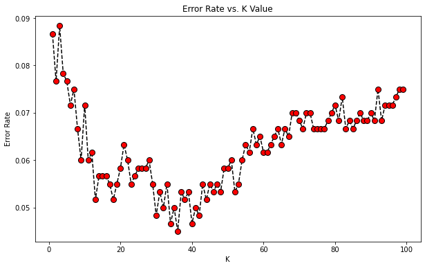

```python
plt.figure(figsize=(10,6))
plt.plot(range(1,100), error_rate,color='black', linestyle='dashed', marker='o', markerfacecolor='red', markersize = 8)
plt.title('Error Rate vs. K Value')
plt.xlabel('K')
plt.ylabel('Error Rate')
```

```python
#從錯誤率最低的k值=36來看：precision、recall、f1-score、support的表現
knn = KNeighborsClassifier(n_neighbors = 36)

knn.fit(x_train,y_train)
pred = knn.predict(x_test)

print('WITH k=36')
print('\n')
print(confusion_matrix(y_test, pred))
print('\n')
print(classification_report(y_test, pred))
```

```
WITH k=36


[[144   2   0   0]
 [  4 149   2   0]
 [  0  11 133   3]
 [  0   0   5 147]]


              precision    recall  f1-score   support

           0       0.97      0.99      0.98       146
           1       0.92      0.96      0.94       155
           2       0.95      0.90      0.93       147
           3       0.98      0.97      0.97       152

    accuracy                           0.95       600
   macro avg       0.96      0.95      0.95       600
weighted avg       0.96      0.95      0.95       600
```

```python
sum(y_test == pred)/len(y_test)
```

```
0.955
```

## Multinomial Logit

Use **Logistic Regression** to train your logit model with **LogisticRegression(multi_class='multinomial', solver ='newton-cg')**. This will provide you with multinomial logistic model which can classify multiple classes. What is your precision rate for your multinomial logistic model?

```python
from sklearn.linear_model import LogisticRegression
logit_model = LogisticRegression(multi_class = 'multinomial', solver = 'newton-cg')
logit_model.fit(x_train, y_train)
```

```
LogisticRegression(multi_class='multinomial', solver='newton-cg')
```

```python
predictions_logit = logit_model.predict(x_test)
(y_test == predictions_logit).mean()
```

```
0.9633333333333334
```

```python
print(classification_report(y_test, predictions_logit))
```

```
              precision    recall  f1-score   support

           0       0.99      0.96      0.97       146
           1       0.95      0.94      0.94       155
           2       0.94      0.97      0.95       147
           3       0.97      0.99      0.98       152

    accuracy                           0.96       600
   macro avg       0.96      0.96      0.96       600
weighted avg       0.96      0.96      0.96       600
```

## Decision Tree

Use Decision Tree algorithm to train your model. What is your highest precision rate for your DT model? (Hint: You can play with different parameters to see if you can gain better predictions.)

```python
from sklearn.tree import DecisionTreeClassifier
dtree = DecisionTreeClassifier()
dtree.fit(x_train, y_train)
```

```
DecisionTreeClassifier()
```

```python
from sklearn.metrics import classification_report,confusion_matrix
predictions = dtree.predict(x_test)
(y_test == predictions).mean()
```

```
0.8383333333333334
```

```python
print(confusion_matrix(y_test, predictions))
print('\n')
print(classification_report(y_test, predictions))
```

```
[[126  20   0   0]
 [ 10 122  23   0]
 [  0  15 117  15]
 [  0   0  14 138]]


              precision    recall  f1-score   support

           0       0.93      0.86      0.89       146
           1       0.78      0.79      0.78       155
           2       0.76      0.80      0.78       147
           3       0.90      0.91      0.90       152

    accuracy                           0.84       600
   macro avg       0.84      0.84      0.84       600
weighted avg       0.84      0.84      0.84       600
```

## Random Forest

Use Random Forest algorithm to train your model. What is your highest precision rate for your Random Forest model? (Hint: You can play with different parameters to see if you can gain better predictions.)

```python
from sklearn.ensemble import RandomForestClassifier
rfc = RandomForestClassifier(n_estimators = 100)
rfc.fit(x_train, y_train)
```

```
RandomForestClassifier()
```

```python
predictions = rfc.predict(x_test)
(y_test == predictions).mean()
```

```
0.875
```

```python
print(confusion_matrix(y_test, predictions))
print('\n')
print(classification_report(y_test, predictions))
```

```
[[135  11   0   0]
 [ 10 130  15   0]
 [  0  21 118   8]
 [  0   0  10 142]]


              precision    recall  f1-score   support

           0       0.93      0.92      0.93       146
           1       0.80      0.84      0.82       155
           2       0.83      0.80      0.81       147
           3       0.95      0.93      0.94       152

    accuracy                           0.88       600
   macro avg       0.88      0.88      0.88       600
weighted avg       0.88      0.88      0.88       600
```

```python
#利用for loop來建立迴圈，選擇n值
error_rf_rate = []

for i in range(1,20):
    rf = KNeighborsClassifier(n_neighbors=10*i)
    rf.fit(x_train, y_train)
    predit_i = rf.predict(x_test)
    error_rf_rate.append(np.mean(predit_i != y_test))
```

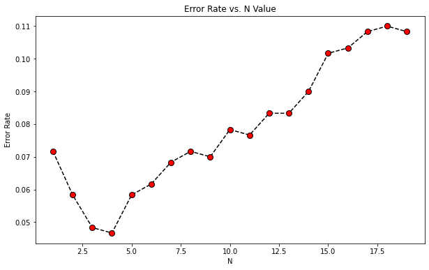

```python
plt.figure(figsize = (10,6))
plt.plot(range(1,20), error_rf_rate, color='black', linestyle='dashed', marker='o', markerfacecolor='red', markersize = 8)
plt.title('Error Rate vs. N Value')
plt.xlabel('N')
plt.ylabel('Error Rate')
```

```python
from sklearn.ensemble import RandomForestClassifier
rfc = RandomForestClassifier(n_estimators = 40)
rfc.fit(x_train, y_train)
```

```
RandomForestClassifier(n_estimators=40)
```

```python
predictions = rfc.predict(x_test)
(y_test == predictions).mean()
```

```
0.8733333333333333
```

```python
print(confusion_matrix(y_test, predictions))
print('\n')
print(classification_report(y_test, predictions))
```

```
[[134  12   0   0]
 [ 11 131  13   0]
 [  0  25 116   6]
 [  0   0   9 143]]


              precision    recall  f1-score   support

           0       0.92      0.92      0.92       146
           1       0.78      0.85      0.81       155
           2       0.84      0.79      0.81       147
           3       0.96      0.94      0.95       152

    accuracy                           0.87       600
   macro avg       0.88      0.87      0.87       600
weighted avg       0.88      0.87      0.87       600
```